# Getting started with `sparklyr`

Spark notes

R is a fantastic resource for data analysis and modeling, but it limits you to work on datasets that you can comfortably hold in the local RAM on your machine. Modern R offers the tidyverse which, as you’ve seen, is a really convenient syntax for transforming and visualising data.

Spark is a platform for cluster computing, which lets you spread data and computation over multiple machines in a cluster, opening up new opportunities to work on large data sets.

The `sparklyr` package gives us the best of both worlds! It lets us use convenient `dplyr`-like syntax to manipulate data, but converts those commands into code Spark can understand and dispatches them to a connected Spark cluster, so we can deal efficiently with big data problems.

A word of caution is in order though: `sparklyr` is very new, and features are rapidly evolving, so you must expect changes in how you work with the package in the short term.

```r
library("sparklyr")
spark_available_versions(show_minor = TRUE)
```

| spark |
| --- |
| 1.6.3 |
| 1.6.2 |
| 1.6.1 |
| 1.6.0 |
| 2.0.0 |
| 2.0.1 |
| 2.0.2 |
| 2.1.0 |
| 2.1.1 |
| 2.2.0 |

[output cut: 11 more lines]

```r
spark_install(version = "2.4.5")
```

```r
spark_installed_versions()
```

| spark | hadoop | dir |
| --- | --- | --- |
| 2.4.5 | 2.7 | /Users/codeclan/spark/spark-2.4.5-bin-hadoop2.7 |

Now connect to the Spark you just installed. To do this, we pass an argument `master = "local"`, which lets `sparklyr` know that our **local** machine (i.e. your laptop) is being used as the **master** (or **driver node**) of a Spark ‘cluster’ - in this case, just the master itself.

```r
sc <- spark_connect(master = "local", version = "2.4.5")
```

Let’s copy some data to Spark

```r
library(tidyverse)
library(janitor)
avocados<- read_csv("data/avocado.csv")
avocados <- avocados %>%
  clean_names()
avocados_spark <- copy_to(sc, avocados)
```

If we had lost the reference to `avocados` locally, we can recreate it in this way

```r
avocados_spark <- tbl(sc, "avocados")
```

```r
src_tbls(sc)
```

```
[1] "avocados"
```

```r
class(avocados_spark)
```

```
[1] "tbl_spark" "tbl_sql"   "tbl_lazy"  "tbl"
```

If we look inside this `tbl_spark` it doesn’t actually contain any data, instead it points to a data source, i.e. Spark in this case. In this way, we avoid ever having to deal with all the data in Spark memory in the memory of the local machine. This is an example of ‘lazy evaluation’ - don’t actually acquire and deal with the data until the processing need arises.

```r
str(avocados)
```

```
List of 2
 $ src:List of 1
  ..$ con:List of 13
  .. ..$ master      : chr "local[4]"
  .. ..$ method      : chr "shell"
  .. ..$ app_name    : chr "sparklyr"
  .. ..$ config      :List of 6
  .. .. ..$ spark.env.SPARK_LOCAL_IP.local           : chr "127.0.0.1"
  .. .. ..$ sparklyr.connect.csv.embedded            : chr "^1.*"
  .. .. ..$ spark.sql.legacy.utcTimestampFunc.enabled: logi TRUE
  .. .. ..$ sparklyr.connect.cores.local             : int 4
  .. .. ..$ spark.sql.shuffle.partitions.local       : int 4
  .. .. ..$ sparklyr.shell.driver-memory             : chr "2g"
  .. .. ..- attr(*, "config")= chr "default"
  .. .. ..- attr(*, "file")= chr "/Library/Frameworks/R.framework/Versions/3.6/Resources/library/sparklyr/conf/config-template.yml"
  .. ..$ state       :<environment: 0x7f8640f91c68>
  .. ..$ extensions  :List of 4
  .. .. ..$ jars        : chr(0)
  .. .. ..$ packages    : chr(0)
  .. .. ..$ initializers: list()
  .. .. ..$ catalog_jars: chr(0)
  .. ..$ spark_home  : chr "/Users/codeclan/spark/spark-2.4.5-bin-hadoop2.7"
  .. ..$ backend     : 'sockconn' int 4
  .. .. ..- attr(*, "conn_id")=<externalptr>
  .. ..$ monitoring  : 'sockconn' int 5
  .. .. ..- attr(*, "conn_id")=<externalptr>
  .. ..$ gateway     : 'sockconn' int 3
  .. .. ..- attr(*, "conn_id")=<externalptr>
  .. ..$ output_file : chr "/var/folders/pb/hvbmw9y13pl4q2c6_l4d_z_m0000gn/T//RtmpO5g3iD/file1077652557052_spark.log"
  .. ..$ sessionId   : num 7390
  .. ..$ home_version: chr "2.4.5"
  .. ..- attr(*, "class")= chr [1:3] "spark_connection" "spark_shell_connection" "DBIConnection"
  ..- attr(*, "class")= chr [1:3] "src_spark" "src_sql" "src"
 $ ops:List of 2
  ..$ x   : 'ident' chr "avocados"
  ..$ vars: chr [1:14] "x1" "date" "average_price" "total_volume" ...
  ..- attr(*, "class")= chr [1:3] "op_base_remote" "op_base" "op"
 - attr(*, "class")= chr [1:4] "tbl_spark" "tbl_sql" "tbl_lazy" "tbl"
```

We can see that the `avocados_spark` object is much smaller than the original `avocados` tibble using the `object_size()` function from the `pryr` package

```r
library(pryr)
object_size(avocados)
```

```
2.06 MB
```

```r
object_size(avocados_spark)
```

```
45 kB
```

```r
object_size(avocados_spark %>% collect())
```

```
2.05 MB
```

```r
glimpse(avocados)
```

```
Rows: ??
Columns: 14
Database: spark_connection
$ x1            <dbl> 0, 1, 2, 3, 4, 5, 6, 7, 8, 9, 10, 11, 12, 13, 14, 15, 16, 17, 18, 19, 20, 21, 22, 23, …
$ date          <date> 2015-12-27, 2015-12-20, 2015-12-13, 2015-12-06, 2015-11-29, 2015-11-22, 2015-11-15, 2…
$ average_price <dbl> 1.33, 1.35, 0.93, 1.08, 1.28, 1.26, 0.99, 0.98, 1.02, 1.07, 1.12, 1.28, 1.31, 0.99, 1.…
$ total_volume  <dbl> 64236.62, 54876.98, 118220.22, 78992.15, 51039.60, 55979.78, 83453.76, 109428.33, 9981…
$ x4046         <dbl> 1036.74, 674.28, 794.70, 1132.00, 941.48, 1184.27, 1368.92, 703.75, 1022.15, 842.40, 9…
$ x4225         <dbl> 54454.85, 44638.81, 109149.67, 71976.41, 43838.39, 48067.99, 73672.72, 101815.36, 8731…
$ x4770         <dbl> 48.16, 58.33, 130.50, 72.58, 75.78, 43.61, 93.26, 80.00, 85.34, 113.00, 117.07, 105.32…
$ total_bags    <dbl> 8696.87, 9505.56, 8145.35, 5811.16, 6183.95, 6683.91, 8318.86, 6829.22, 11388.36, 8625…
$ small_bags    <dbl> 8603.62, 9408.07, 8042.21, 5677.40, 5986.26, 6556.47, 8196.81, 6266.85, 11104.53, 8061…
$ large_bags    <dbl> 93.25, 97.49, 103.14, 133.76, 197.69, 127.44, 122.05, 562.37, 283.83, 564.45, 327.80, …
$ x_large_bags  <dbl> 0.00, 0.00, 0.00, 0.00, 0.00, 0.00, 0.00, 0.00, 0.00, 0.00, 0.00, 0.00, 0.00, 0.00, 0.…
$ type          <chr> "conventional", "conventional", "conventional", "conventional", "conventional", "conve…
$ year          <dbl> 2015, 2015, 2015, 2015, 2015, 2015, 2015, 2015, 2015, 2015, 2015, 2015, 2015, 2015, 20…
$ region        <chr> "Albany", "Albany", "Albany", "Albany", "Albany", "Albany", "Albany", "Albany", "Alban…
```

```r
spark_web(sc)
```

```r
library(DBI)
dbGetQuery(sc, "SELECT COUNT(*) FROM avocados")
```

| count(1) |
| --- |
| 18249 |

```r
avocados %>%
  count()
```

| n |
| --- |
| 18249 |

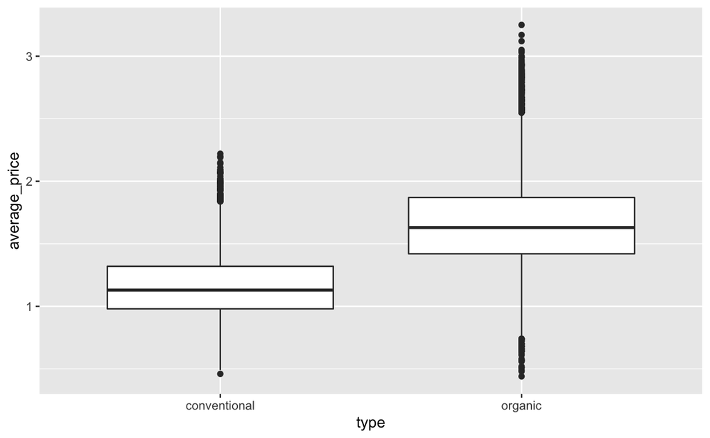

```r
avocados %>%
  ggplot(aes(x = type, y = average_price)) +
  geom_boxplot()
```

```r
fit <- avocados %>%
  ml_linear_regression(average_price ~ total_volume)
```

```r
library(modelr)
tidy(fit)
```

| term | estimate | std.error | statistic | p.value |
| --- | --- | --- | --- | --- |
| (Intercept) | 1.425096e+00 | 3.012436e-03 | 473.07106 | 0 |
| total_volume | -2.247455e-08 | 8.469816e-10 | -26.53487 | 0 |

```r
glance(fit)
```

| explained.variance | mean.absolute.error | mean.squared.error | r.squared | root.mean.squared.error |
| --- | --- | --- | --- | --- |
| 0.006024048 | 0.3178092 | 0.1561155 | 0.03715348 | 0.3951145 |

```r
library(broom)
augment(fit)
```

| x1 | date | average_price | total_volume | x4046 | x4225 | x4770 | total_bags | small_bags | large_bags | x_large_bags | type | year | region | fitted | resid |
| --- | --- | --- | --- | --- | --- | --- | --- | --- | --- | --- | --- | --- | --- | --- | --- |
| 0 | 2015-12-27 | 1.33 | 64236.62 | 1036.74 | 54454.85 | 48.16 | 8696.87 | 8603.62 | 93.25 | 0.00 | conventional | 2015 | Albany | 1.423653 | -0.093652560 |
| 1 | 2015-12-20 | 1.35 | 54876.98 | 674.28 | 44638.81 | 58.33 | 9505.56 | 9408.07 | 97.49 | 0.00 | conventional | 2015 | Albany | 1.423863 | -0.073862913 |
| 2 | 2015-12-13 | 0.93 | 118220.22 | 794.70 | 109149.67 | 130.50 | 8145.35 | 8042.21 | 103.14 | 0.00 | conventional | 2015 | Albany | 1.422439 | -0.492439303 |
| 3 | 2015-12-06 | 1.08 | 78992.15 | 1132.00 | 71976.41 | 72.58 | 5811.16 | 5677.40 | 133.76 | 0.00 | conventional | 2015 | Albany | 1.423321 | -0.343320936 |
| 4 | 2015-11-29 | 1.28 | 51039.60 | 941.48 | 43838.39 | 75.78 | 6183.95 | 5986.26 | 197.69 | 0.00 | conventional | 2015 | Albany | 1.423949 | -0.143949157 |
| 5 | 2015-11-22 | 1.26 | 55979.78 | 1184.27 | 48067.99 | 43.61 | 6683.91 | 6556.47 | 127.44 | 0.00 | conventional | 2015 | Albany | 1.423838 | -0.163838128 |
| 6 | 2015-11-15 | 0.99 | 83453.76 | 1368.92 | 73672.72 | 93.26 | 8318.86 | 8196.81 | 122.05 | 0.00 | conventional | 2015 | Albany | 1.423221 | -0.433220663 |
| 7 | 2015-11-08 | 0.98 | 109428.33 | 703.75 | 101815.36 | 80.00 | 6829.22 | 6266.85 | 562.37 | 0.00 | conventional | 2015 | Albany | 1.422637 | -0.442636896 |
| 8 | 2015-11-01 | 1.02 | 99811.42 | 1022.15 | 87315.57 | 85.34 | 11388.36 | 11104.53 | 283.83 | 0.00 | conventional | 2015 | Albany | 1.422853 | -0.402853032 |
| 9 | 2015-10-25 | 1.07 | 74338.76 | 842.40 | 64757.44 | 113.00 | 8625.92 | 8061.47 | 564.45 | 0.00 | conventional | 2015 | Albany | 1.423426 | -0.353425519 |

[output cut: 990 more lines]

Mutating to add features

```r
avocados <- avocados %>%
  mutate(average_over_1.40 = average_price > 1.40)
```

[output not shown]

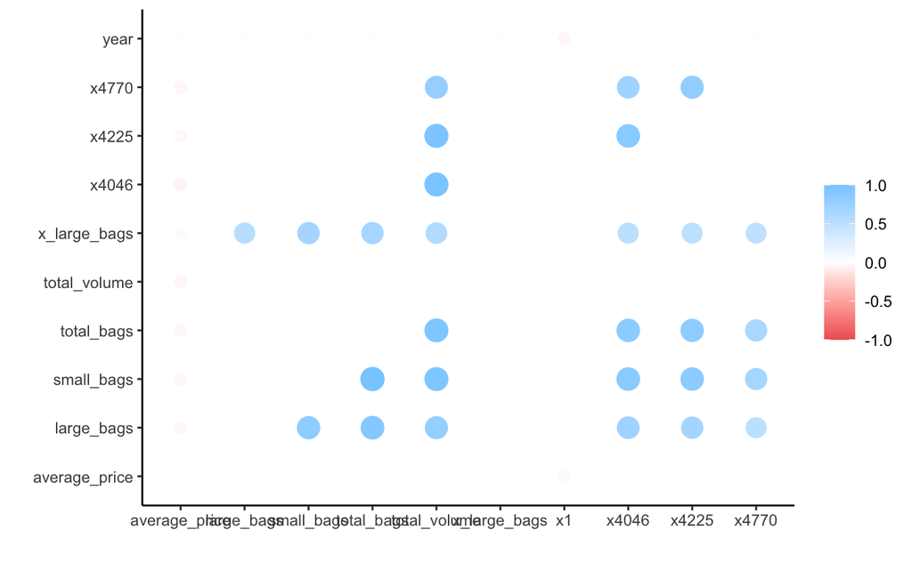

```r
library(corrr)
avocados %>%
  select(-c("date", "type", "region", "average_over_1.40")) %>%
  correlate(use = "pairwise.complete.obs", method = "pearson") %>%
  shave() %>%
  rplot()
```

```r
NA
```

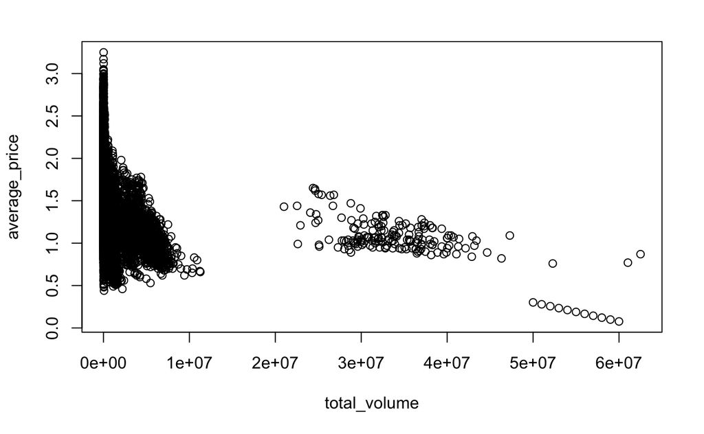

```r
fit %>%
  ml_predict(copy_to(sc, data.frame(total_volume = seq(5e7, 6e7, 1e6)))) %>%
  transmute(total_volume = total_volume, average_price = prediction) %>%
  full_join(select(avocados, total_volume, average_price)) %>%
  collect() %>%
  plot()
```

# Streaming

```r
dir.create("input")
```

```
'input' already exists
```

```r
write.csv(mtcars, "input/cars_1.csv", row.names = F)
```

```r
stream <- stream_read_csv(sc, "input/") %>%
    select(mpg, cyl, disp) %>%
    stream_write_csv("output/")
```

```r
dir("output", pattern = ".csv")
```

```
[1] "part-00000-d147a643-1fd9-480a-ac9a-bfd2c134f053-c000.csv"
[2] "part-00000-f2b95e53-8fed-4359-a290-7d96dd45af12-c000.csv"
```

```r
# Write more data into the stream source
write.csv(mtcars, "input/cars_2.csv", row.names = F)
```

```r
dir("output", pattern = ".csv")
```

```
[1] "part-00000-d147a643-1fd9-480a-ac9a-bfd2c134f053-c000.csv"
[2] "part-00000-f2b95e53-8fed-4359-a290-7d96dd45af12-c000.csv"
```

```r
stream_stop(stream)
```

# Logging

```r
spark_log(sc, filter = "sparklyr")
```

[output not shown]

## Disconnecting

```r
spark_disconnect(sc)
```

```r
spark_disconnect_all()
```

```
[1] 0
```